# R Markdown for Reproducibility

2017-January -6

## Acknowledgments

I stole a lot of this work wholesale from people who know more than I do. I thank them and ask their forgiveness.

- Andrew Bray see [Reproducibility 2.0](https://prezi.com/rtmytpb6iwsw/reproducible-20/)
- Nick Horton
- Mine Çetinkaya-Rundel
- Hadley Wickham & Garrett Grolemund, r4ds
- Danny Kaplan – [DataComputing](http://data-computing.org/author/dtkaplan/)
- Amelia McNamara
- Ben Baumer
- Cosma Shalizi - [R Markdown for Class Reports](http://www.stat.cmu.edu/~cshalizi/rmarkdown/)

## R Markdown & Reproducibility

- What happens in a traditional research report?
- Are traditional research reports easily reproducible?
- What gives us *soup to nuts* reproducibility?
- Answer: R Markdown or Scripted LaTeX + STATA
- Works within the TIER framework
- I've implemented a variation of this in an upper-level economics elective

## Questions on your notecard

Please take a couple of minutes to write down a question you have about R Markdown and Reproducibility.

Think about the following ideas:

1. What *problem* could R Markdown (and R Studio) solve for me?
2. What is something I'm *accustomed to doing* that I would want R Markdown (and R Studio) to do for me?
3. What is an *expectation* I have about what I want Simon to cover?

Just take a moment to write down something along these lines for now and put aside your notecard.

## Traditional Reports

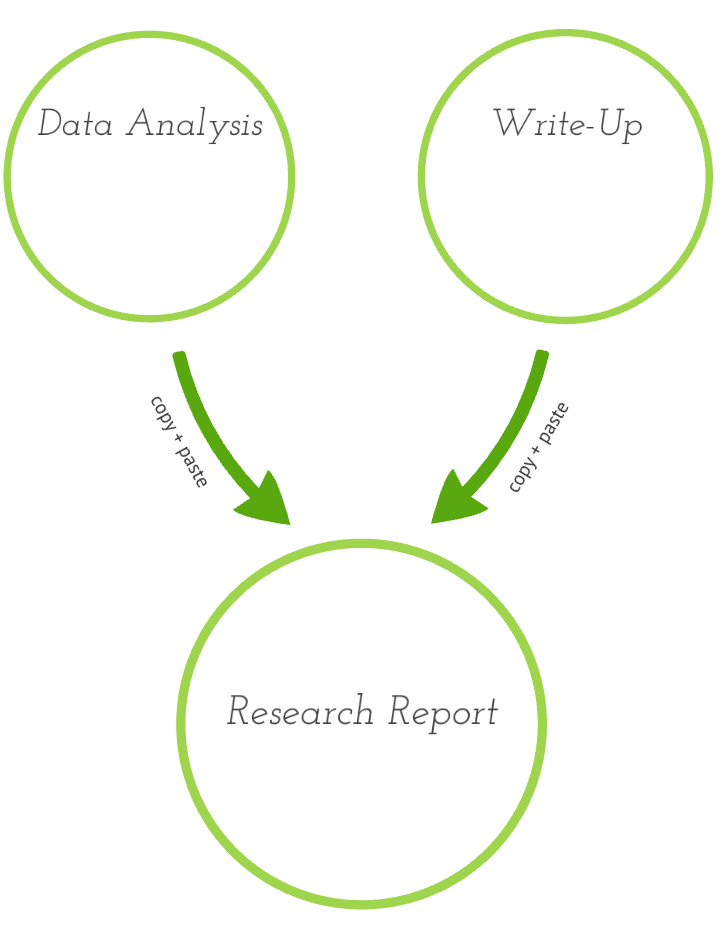

Courtesy of Bray, 2016

The Good

- familiar format, e.g. Word
- easy learning curve

The Bad

- tough for reproducibility
- difficult to update
- mistakes crop up
- teams can't collaborate easily

The Ugly?

- Word/GDocs = Ugly?

## R Markdown Report/Notebook?

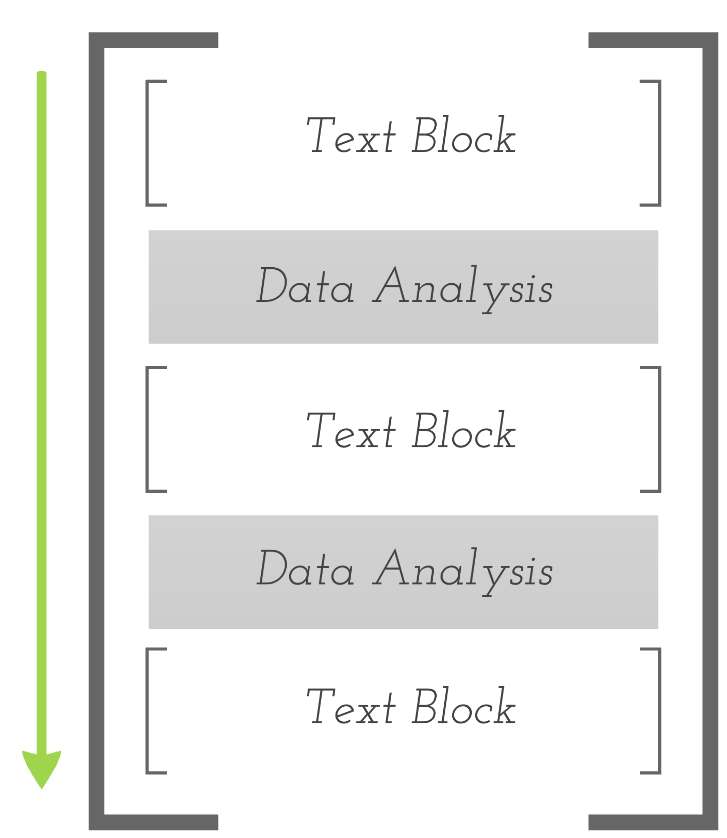

Courtesy of Bray, 2016

The good

- easy to reproduce
- easy to edit/update
- easy to collaborate
- standardized & fast

The bad

- students must learn syntax
- error-free to compile

The ugly?

- inequality in student backgrounds

## Text Formatting

```
# Header 1

## Header 2

### Header 3

This is normal sized text used in the body of our work.

For bullet points, we use dashes, e.g.

- Intro to RStudio
- More content
  - a sub-point
- Back to the original level
```

## Document Types

R Markdown can produce a variety of document types (other than the default `html`):

- `pdf_document` makes a PDF with LaTeX (`.pdf`)
- `word_document` for Microsoft Word documents (`.docx`).
- `odt_document` for OpenDocument Text documents (`.odt`).
- `rtf_document` for Rich Text Format documents (`.rtf`)

And others.

## Data work

Think about data analysis as falling into three loose categories:

- management & wrangling
- visualization & summary statistics
- modeling & inference

All of this occurs in the code "chunk"

## Code chunks

- To open a code chunk hit CMD + OPTION + I on a Mac
- Or type out three backticks ``` folowed by {r}
- And then three more back ticks ``` on another line.
- Within the {r} you can specify options, like {eval = FALSE} if you don't want it to evaluate the code
- Or you can label the code chunk, e.g. {r cars} labels the chunk "cars" in your ToC

## Code Chunk: Example

````markdown
```{r cars, echo = TRUE}
summary(cars)
```
````

The option `echo = TRUE` means that the code gets included in the rendered html.

```r
summary(cars)
```

```
##      speed           dist
##  Min.   : 4.0   Min.   :  2.00
##  1st Qu.:12.0   1st Qu.: 26.00
##  Median :15.0   Median : 36.00
##  Mean   :15.4   Mean   : 42.98
##  3rd Qu.:19.0   3rd Qu.: 56.00
##  Max.   :25.0   Max.   :120.00
```

## Slide with Plot (Reproduction of Sutter, 2009)

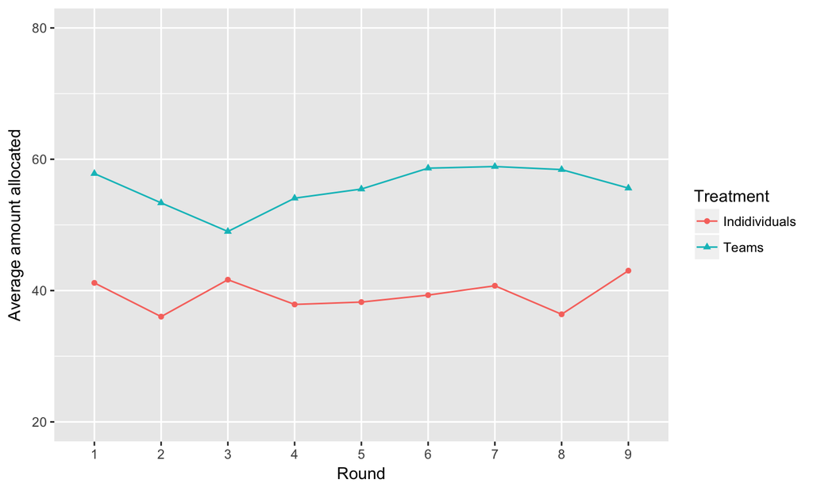

## Dynamic Graphs

[interactive chart not shown]

## Plotly Graphs

[interactive chart not shown]

## Alter and check some data

```
##   session subject  r1  r2  r3  r4  r5  r6  r7  r8  r9  treatment team
## 1       1       1   0   0   0   0  10  10   0   0   0 individual   NA
## 2       1       2   0   0  30  40  40   0   0   0  20 individual   NA
## 3       1       3  30  30   0   0   0  60  60  10   0 individual   NA
## 4       1       4  20   0 100   0   0  30  75 100 100 individual   NA
## 5       1       5 100 100 100 100 100 100 100 100 100 individual   NA
## 6       1       6 100 100 100 100 100 100 100   0   0 individual   NA
##           uniqid
## 1 1_individual_1
## 2 1_individual_2
## 3 1_individual_3
## 4 1_individual_4
## 5 1_individual_5
## 6 1_individual_6
```

## Statistical Tests

```
##
##  Wilcoxon rank sum test with continuity correction
##
## data:  value by treatment
## W = 52876, p-value = 3.838e-10
## alternative hypothesis: true location shift is not equal to 0
```

## Regression output

```
##
## Call:
## lm(formula = value ~ treatment, data = SutNarrow)
##
## Residuals:
##     Min      1Q  Median      3Q     Max
## -61.370 -29.385  -0.542  38.630  60.615
##
## Coefficients:
##                    Estimate Std. Error t value Pr(>|t|)
## (Intercept)          39.385      1.451  27.152  < 2e-16 ***
## treatmentmessage     21.985      1.994  11.028  < 2e-16 ***
## treatmentmixed       10.609      1.925   5.510 3.92e-08 ***
## treatmentpaycomm     10.886      2.144   5.077 4.09e-07 ***
## treatmentteamtreat   16.313      2.629   6.204 6.34e-10 ***
## ---
## Signif. codes:  0 '***' 0.001 '**' 0.01 '*' 0.05 '.' 0.1 ' ' 1
##
## Residual standard error: 34.81 on 2713 degrees of freedom
## Multiple R-squared:  0.04473,    Adjusted R-squared:  0.04333
## F-statistic: 31.76 on 4 and 2713 DF,  p-value: < 2.2e-16
```

## Or a Panel Regression

```
## Oneway (time) effect Random Effect Model
##    (Swamy-Arora's transformation)
##
## Call:
## plm(formula = value ~ treatment, data = SutNarrow, effect = "time",
##     model = "random", index = c("uniqid"))
##
## Balanced Panel: n=302, T=9, N=2718
##
## Effects:
##                    var  std.dev share
## idiosyncratic 1197.631   34.607 0.985
## time            18.044    4.248 0.015
## theta:  0.5755
##
## Residuals :
##    Min. 1st Qu.  Median 3rd Qu.    Max.
##  -62.00  -28.60   -2.67   33.80   64.40
##
## Coefficients :
##                    Estimate Std. Error t-value  Pr(>|t|)
## (Intercept)         39.3854     2.0207 19.4914 < 2.2e-16 ***
## treatmentmessage    21.9850     1.9815 11.0951 < 2.2e-16 ***
## treatmentmixed      10.6093     1.9137  5.5437 3.246e-08 ***
## treatmentpaycomm    10.8862     2.1313  5.1079 3.484e-07 ***
## treatmentteamtreat  16.3130     2.6134  6.2420 4.996e-10 ***
## ---
## Signif. codes:  0 '***' 0.001 '**' 0.01 '*' 0.05 '.' 0.1 ' ' 1
##
## Total Sum of Squares:    3402300
## Residual Sum of Squares: 3248300
## R-Squared:      0.045255
## Adj. R-Squared: 0.045172
## F-statistic: 32.1494 on 4 and 2713 DF, p-value: < 2.22e-16
```

## Math?

How about Bayes' Rule?

\[Pr(\mbox{Outcome} | \mbox{signal}) = \frac{\theta p}{\theta p - (1 - \theta)(1 - p)}\]

R Markdown uses \(\LaTeX\) for math and it immediately gets displayed in R Studio.

That is, \(\LaTeX\) without the challenges of learning the packages, tables, etc that makes learning \(\LaTeX\) so hard.

In-line equations are bracketed by single dollar signs `$`.

Off-set equations are bracketed by double dollar signs `$$`.

## What else?

R Markdown and R Studio together have excellent capabilities.

- R Studio can show you the output of the commands *within* the R Markdown file
- R Studio has *error-detection* and *debugging* assistance for your code (unlike, e.g. STATA or aspects of Excel)
- R Studio server can be hosted online and your students work with logins there

## R Link Love?

New to R?

- Check out the Computation and Visualization Consortium's week-long [workshop](https://www.macalester.edu/hhmi/curricularinnovation/cvc/) over the summer (dates TBC - Kaplan, Prium & Horton)
- Consider subscribing to classes at Datacamp.com (take the intro free of charge)
- Grolemund & Wickham, 2016, *R for Data Science*, r4ds
- Baumer, Horton & Kaplan, forthcoming, [*Modern Data Science with R*](https://www.crcpress.com/Modern-Data-Science-with-R/Baumer-Kaplan-Horton/p/book/9781498724487).

## Notecards again…

- Go back to your notecards
- Re-read them
- Did I cover what you wanted me to cover?
- Do you have *other* or *new* concerns or questions? (write them on the back)
- Chat to someone next to you about what you're thinking about.
- Share with the workshop.
- Yes, you're doing Think-Pair-Share…